# Modeling

Load packages

```r
library(raster)
library(tidyverse)
#library(tidymodels)
library(sf)
library(here)
library(wesanderson)
library(rnaturalearth)
library(patchwork)
```

## Map helpers

```r
pal <- wes_palette("Zissou1", 100, type = "continuous")
world_base <- rnaturalearth::ne_countries(scale = "large", returnclass = "sf") %>%
  select(continent, name_long) %>%
  st_transform(crs = "+proj=cea +lon_0=0 +lat_ts=30 +x_0=0 +y_0=0 +datum=WGS84 +ellps=WGS84 +units=m +no_defs")
```

## Data wrangling

Read in the data. Two main data sources- the genetic summary statistics and the environmental data.

```r
sumstats <- read_csv(here("output", "spreadsheets", "med_3_10_sumstats.csv"))
rast_list <- list.files(here("data", "climate_agg"),
                        pattern = "medium",
                        full.names = TRUE)

rasters_full <- raster::stack(rast_list)
crs(rasters_full) <- "+proj=cea +lon_0=0 +lat_ts=30 +x_0=0 +y_0=0 +datum=WGS84 +ellps=WGS84 +units=m +no_defs"

glimpse(sumstats)
```

```
## Rows: 957
## Columns: 14
## $ cell      <dbl> 5448, 6364, 5631, 6892, 8335, 5629, 4366, 3830, 4546, 3650,…
## $ avg_pi    <dbl> 0.002084775, 0.002351639, 0.002258771, 0.002583159, 0.00207…
## $ median_pi <dbl> 0.001234568, 0.001361903, 0.001374665, 0.001400230, 0.00105…
## $ sqrt_pi   <dbl> 0.04565934, 0.04849370, 0.04752653, 0.05082479, 0.04557316,…
## $ sd_pi     <dbl> 0.002550134, 0.002994169, 0.002636205, 0.003207600, 0.00273…
## $ var_pi    <dbl> 6.503185e-06, 8.965047e-06, 6.949575e-06, 1.028869e-05, 7.4…
## $ num_ind   <dbl> 277738, 7611, 5844, 1541, 1142, 11859, 1430, 1493, 3060, 36…
## $ num_otu   <dbl> 13300, 1192, 877, 270, 189, 1862, 228, 278, 431, 515, 124, …
## $ num_order <dbl> 20, 10, 6, 7, 4, 10, 5, 11, 5, 13, 10, 2, 9, 10, 3, 10, 14,…
## $ hill_1    <dbl> 0.5398728, 0.5119873, 0.5505554, 0.5140907, 0.4974995, 0.55…
## $ hill_2    <dbl> 0.4006171, 0.3817164, 0.4236279, 0.3942914, 0.3670452, 0.42…
## $ hill_3    <dbl> 0.3200303, 0.3080146, 0.3494859, 0.3266356, 0.2928867, 0.35…
## $ hill_4    <dbl> 0.2698272, 0.2641870, 0.3032256, 0.2851218, 0.2492382, 0.30…
## $ hill_5    <dbl> 0.2362016, 0.2362316, 0.2724399, 0.2579253, 0.2216627, 0.27…
```

```r
rasters_full
```

```
## class      : RasterStack
## dimensions : 76, 180, 13680, 47  (nrow, ncol, ncell, nlayers)
## resolution : 193000, 193000  (x, y)
## extent     : -17367530, 17372470, -7371287, 7296713  (xmin, xmax, ymin, ymax)
## crs        : +proj=cea +lon_0=0 +lat_ts=30 +x_0=0 +y_0=0 +datum=WGS84 +ellps=WGS84 +units=m +no_defs +towgs84=0,0,0
## names      : current_medium_bio_1, current_medium_bio_10, current_medium_bio_11, current_medium_bio_12, current_medium_bio_13, current_medium_bio_14, current_medium_bio_15, current_medium_bio_16, current_medium_bio_17, current_medium_bio_18, current_medium_bio_19, current_medium_bio_2, current_me…
## min values :        -4.982007e+02,         -2.849049e+02,         -6.102445e+02,          0.000000e+00,          0.000000e+00,          0.000000e+00,          6.131367e+00,          0.000000e+00,          0.000000e+00,          0.000000e+00,          0.000000e+00,         6.035902e+00,         6.…
## max values :         3.038677e+02,          3.792534e+02,          2.788001e+02,          7.643655e+03,          1.221808e+03,          3.532195e+02,          3.318449e+02,          3.467678e+03,          1.085473e+03,          2.137986e+03,          2.477678e+03,         1.511488e+02,         7.…
```

Extract raster values for each cell that has genetic summary data and join the data frames for a full data set.

```r
explanatory_df <- rasters_full[sumstats$cell] %>%
  as_tibble() %>%
  mutate(cell = sumstats$cell)


full_df <- left_join(sumstats, explanatory_df, by = "cell") %>%
  # convert soil classifications to a factor
  mutate(soil_medium_hwsd = as.factor(soil_medium_hwsd)) %>%
  # arrange for plotting later
  arrange(cell)

glimpse(full_df)
```

```
## Rows: 957
## Columns: 61
## $ cell                     <dbl> 48, 52, 55, 59, 96, 97, 98, 192, 211, 230, 2…
## $ avg_pi                   <dbl> 0.001454716, 0.001984298, 0.001503509, 0.001…
## $ median_pi                <dbl> 0.0000000000, 0.0008151743, 0.0006496771, 0.…
## $ sqrt_pi                  <dbl> 0.03814074, 0.04454546, 0.03877511, 0.037239…
## $ sd_pi                    <dbl> 0.002743044, 0.002742850, 0.002959823, 0.001…
## $ var_pi                   <dbl> 7.524288e-06, 7.523227e-06, 8.760551e-06, 3.…
## $ num_ind                  <dbl> 168, 5839, 3080, 122, 937, 392, 614, 660, 20…
## $ num_otu                  <dbl> 31, 97, 44, 13, 47, 35, 68, 37, 74, 19, 106,…
## $ num_order                <dbl> 3, 2, 2, 3, 5, 3, 2, 2, 3, 2, 4, 6, 3, 6, 8,…
## $ hill_1                   <dbl> 0.3062532, 0.4725420, 0.3445770, 0.4787828, …
## $ hill_2                   <dbl> 0.2251809, 0.3459020, 0.2088839, 0.3557687, …
## $ hill_3                   <dbl> 0.1876479, 0.2870740, 0.1535659, 0.2968241, …
## $ hill_4                   <dbl> 0.1680376, 0.2531603, 0.1293904, 0.2668610, …
```

[output cut: 48 more lines]

Convert this to a `sf` polygon object for mapping and spatial cross validation.

```r
template_medium <- raster(here("data", "templates", "template_medium.tif"))

template_medium[full_df$cell] <- full_df$avg_pi

full_sf <- rasterToPolygons(template_medium) %>%
  st_as_sf() %>%
  bind_cols(full_df) %>%
  select(-template_medium) %>%
  # Adding continent and country columns to the data frame.
  st_join(world_base["continent"], largest = TRUE)
glimpse(full_sf)
```

```
## Rows: 957
## Columns: 63
## $ cell                     <dbl> 48, 52, 55, 59, 96, 97, 98, 192, 211, 230, 2…
## $ avg_pi                   <dbl> 0.001454716, 0.001984298, 0.001503509, 0.001…
## $ median_pi                <dbl> 0.0000000000, 0.0008151743, 0.0006496771, 0.…
## $ sqrt_pi                  <dbl> 0.03814074, 0.04454546, 0.03877511, 0.037239…
## $ sd_pi                    <dbl> 0.002743044, 0.002742850, 0.002959823, 0.001…
## $ var_pi                   <dbl> 7.524288e-06, 7.523227e-06, 8.760551e-06, 3.…
## $ num_ind                  <dbl> 168, 5839, 3080, 122, 937, 392, 614, 660, 20…
## $ num_otu                  <dbl> 31, 97, 44, 13, 47, 35, 68, 37, 74, 19, 106,…
## $ num_order                <dbl> 3, 2, 2, 3, 5, 3, 2, 2, 3, 2, 4, 6, 3, 6, 8,…
## $ hill_1                   <dbl> 0.3062532, 0.4725420, 0.3445770, 0.4787828, …
## $ hill_2                   <dbl> 0.2251809, 0.3459020, 0.2088839, 0.3557687, …
## $ hill_3                   <dbl> 0.1876479, 0.2870740, 0.1535659, 0.2968241, …
## $ hill_4                   <dbl> 0.1680376, 0.2531603, 0.1293904, 0.2668610, …
```

[output cut: 50 more lines]

Visualizing temperature to make sure the conversion was successful.

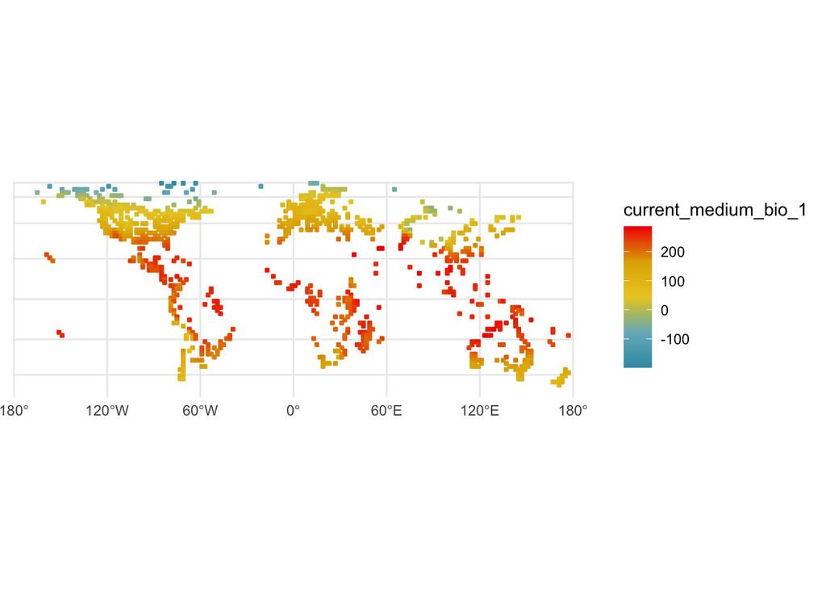

```r
ggplot() +
  geom_sf(data = full_sf, aes(fill = current_medium_bio_1, color = current_medium_bio_1)) +
  scale_fill_gradientn(colors = pal) +
  scale_color_gradientn(colors = pal) +
  theme_minimal()
```

### Continent mapping

How many cells successfully mapped to a continent, and what is the sample size? Looks like 1 cells did not map correctly.

```r
full_sf %>%
  count(continent)
```

```
## Simple feature collection with 8 features and 2 fields
## geometry type:  GEOMETRY
## dimension:      XY
## bbox:           xmin: -16016530 ymin: -5441287 xmax: 17179470 ymax: 7296713
## CRS:            +proj=cea +lon_0=0 +lat_ts=30 +x_0=0 +y_0=0 +datum=WGS84 +units=m +no_defs +ellps=WGS84 +towgs84=0,0,0
## # A tibble: 8 x 3
##   continent             n                                               geometry
##   <chr>             <int>                                         <GEOMETRY [m]>
## 1 Africa              115 MULTIPOLYGON (((2511470 -3897287, 2704470 -3897287, 2…
## 2 Asia                163 MULTIPOLYGON (((5020470 4208713, 5020470 4015713, 482…
## 3 Europe              155 MULTIPOLYGON (((-190530.4 4401713, -190530.4 4208713,…
## 4 North America       318 MULTIPOLYGON (((-9068530 3629713, -9068530 3436713, -…
## 5 Oceania             110 MULTIPOLYGON (((11582470 -4090287, 11582470 -4283287,…
## 6 Seven seas (open…     5 MULTIPOLYGON (((3862470 -2739287, 4055470 -2739287, 4…
## 7 South America        90 MULTIPOLYGON (((-5594530 -4090287, -5401530 -4090287,…
## 8 <NA>                  1 POLYGON ((-7717530 927713.1, -7524530 927713.1, -7524…
```

Visualize which cells mapped correctly. All of the “Open Ocean” values are islands around Africa. Although these may politically be assigned a different continent (e.g. some islands around Madagascar are European), spatially they’re near Africa, so I’m classifying them as African.

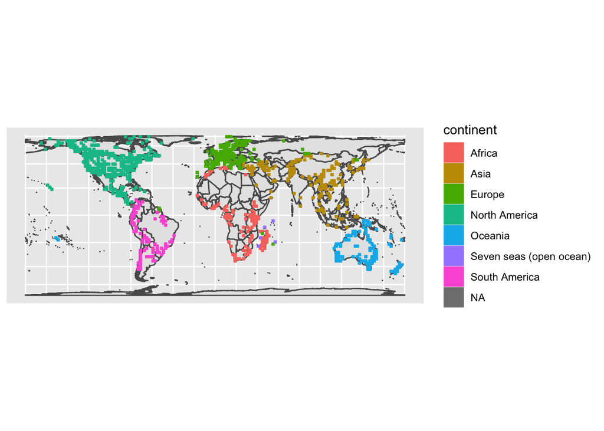

```r
ggplot() +
  geom_sf(data = world_base) +
  geom_sf(data = full_sf, aes(fill = continent, color = continent))
```

Converting the cells and taking another look. Looks fine, except for the NA.

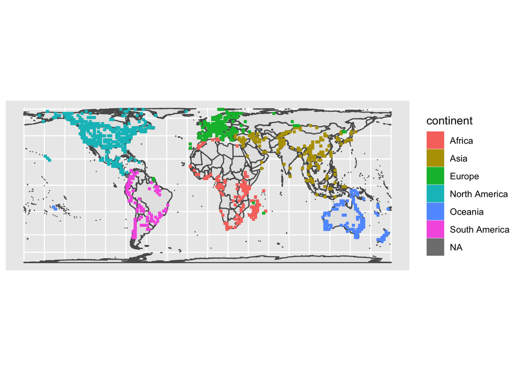

```r
full_sf <- full_sf %>%
  mutate(continent = ifelse(str_detect(continent, "Seven"), "Africa", continent))

ggplot() +
  geom_sf(data = world_base) +
  geom_sf(data = full_sf, aes(fill = continent, color = continent))
```

Let’s see where the NA is. Looks like South America!

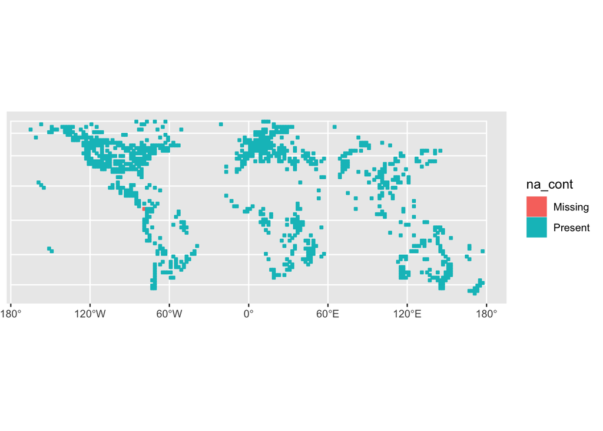

```r
full_sf %>%
  mutate(na_cont = if_else(is.na(continent), "Missing", "Present")) %>%
  ggplot() +
  geom_sf(aes(fill = na_cont, color = na_cont))
```

Replacing the NA value with “South America”. North America has the most representation, while South America has the least.

```r
full_complete <- full_sf %>%
  mutate(continent = if_else(is.na(continent), "South America", continent))

count(full_complete, continent) %>% mutate(perc = n / sum(n)) %>%
  as_tibble() %>%
  select(continent, n, perc) %>%
  arrange(desc(perc)) %>%
  knitr::kable()
```

| continent | n | perc |
| --- | --- | --- |
| North America | 318 | 0.3322884 |
| Asia | 163 | 0.1703239 |
| Europe | 155 | 0.1619645 |
| Africa | 120 | 0.1253918 |
| Oceania | 110 | 0.1149425 |
| South America | 91 | 0.0950888 |

### Predictor variables

Plant phylogenetic diversity has an excessive number of NAs (56). May need to throw out. Others have between 0 and 3 NAs. Need to see if these are for the same cells or not

```r
full_complete %>%
  summarize_all(~sum(is.na(.))) %>%
  pivot_longer(cols = !contains("geometry"),
               names_to = "variable",
               values_to = "num_NA") %>%
  filter(num_NA > 0)
```

```
## # A tibble: 20 x 3
##                                                 geometry variable         num_NA
##                                       <MULTIPOLYGON [m]> <chr>             <int>
##  1 (((11582470 -4090287, 11582470 -4283287, 11389470 -4… dhi_medium_cum        1
##  2 (((11582470 -4090287, 11582470 -4283287, 11389470 -4… dhi_medium_min        1
##  3 (((11582470 -4090287, 11582470 -4283287, 11389470 -4… dhi_medium_var        1
##  4 (((11582470 -4090287, 11582470 -4283287, 11389470 -4… ghh_medium_corr…      1
##  5 (((11582470 -4090287, 11582470 -4283287, 11389470 -4… ghh_medium_entr…      1
##  6 (((11582470 -4090287, 11582470 -4283287, 11389470 -4… ghh_medium_even…      1
##  7 (((11582470 -4090287, 11582470 -4283287, 11389470 -4… ghh_medium_homo…      1
##  8 (((11582470 -4090287, 11582470 -4283287, 11389470 -4… ghh_medium_maxi…      1
##  9 (((11582470 -4090287, 11582470 -4283287, 11389470 -4… ghh_medium_range      1
## 10 (((11582470 -4090287, 11582470 -4283287, 11389470 -4… ghh_medium_shan…      1
## 11 (((11582470 -4090287, 11582470 -4283287, 11389470 -4… ghh_medium_simp…      1
## 12 (((11582470 -4090287, 11582470 -4283287, 11389470 -4… ghh_medium_std_…      1
## 13 (((11582470 -4090287, 11582470 -4283287, 11389470 -4… ghh_medium_unif…      1
## 14 (((11582470 -4090287, 11582470 -4283287, 11389470 -4… plant_medium_pl…     56
## 15 (((11582470 -4090287, 11582470 -4283287, 11389470 -4… stability_preci…      1
## 16 (((11582470 -4090287, 11582470 -4283287, 11389470 -4… stability_temp_…      1
## 17 (((11582470 -4090287, 11582470 -4283287, 11389470 -4… terrain_medium_…      3
## 18 (((11582470 -4090287, 11582470 -4283287, 11389470 -4… terrain_medium_…      3
## 19 (((11582470 -4090287, 11582470 -4283287, 11389470 -4… terrain_medium_…      3
## 20 (((11582470 -4090287, 11582470 -4283287, 11389470 -4… terrain_medium_…      3
```

It seems like the missing data from most variables are the same cells (four total cells with na)

```r
nrow_filt <- full_complete %>%
  select(-plant_medium_plant_phylo) %>%
  na.omit() %>%
  nrow()

nrow(full_complete) - nrow_filt
```

```
## [1] 4
```

#### Plant richness

Let’s visualize where the plant richness diversity missing data is. It looks like the missing data is restricted to somewhat randomly distributed islands, including New Zealand. Let’s explore a bit more to see if it would be worth diving into the data to fill in the missing values.

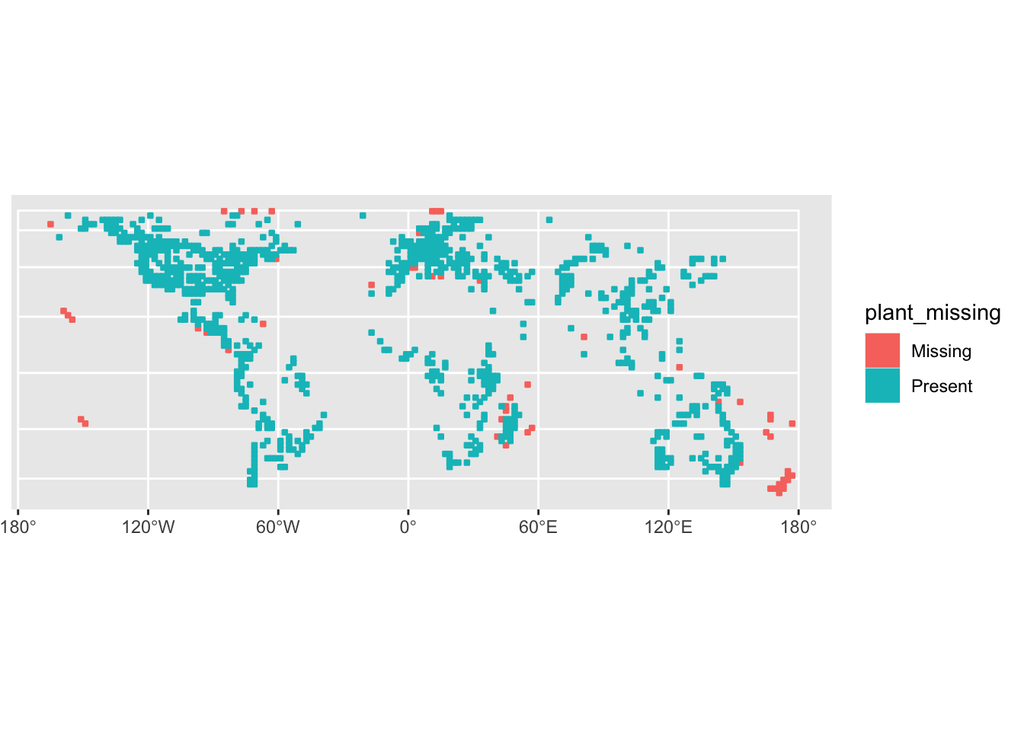

```r
full_complete %>%
  mutate(plant_missing =
           if_else(is.na(plant_medium_plant_phylo), "Missing", "Present")) %>%
  ggplot() +
  geom_sf(aes(fill = plant_missing, color = plant_missing))
```

If there’s no linear relationship with a Hill One or Average pi, then I’m just going to throw it out.

Plots don’t look like much:

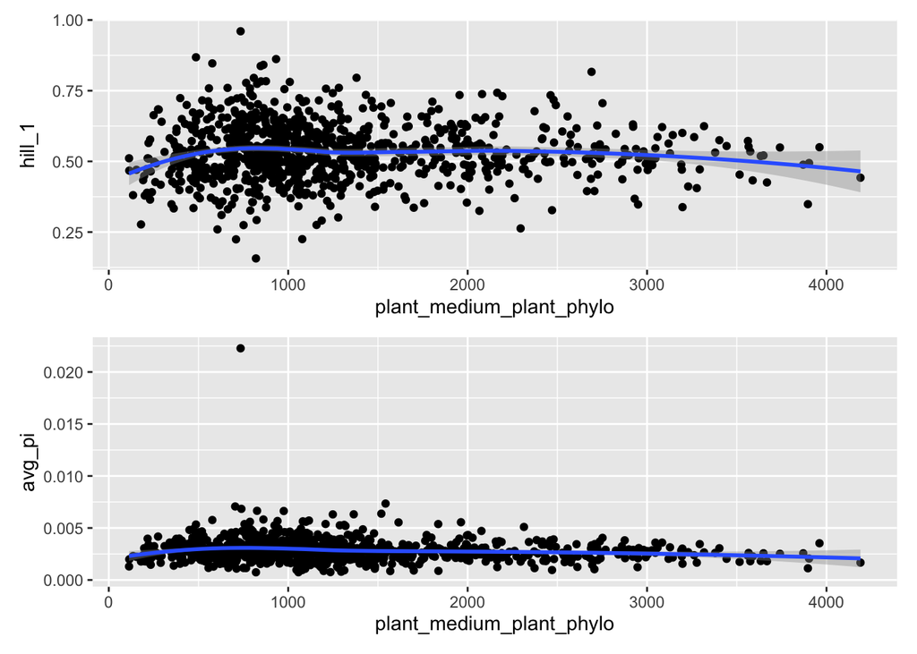

```r
p_hill <- ggplot(data = full_complete, aes(x = plant_medium_plant_phylo, y = hill_1)) +
  geom_point() +
  geom_smooth()

p_pi <- ggplot(data = full_complete, aes(x = plant_medium_plant_phylo, y = avg_pi)) +
  geom_point() +
  geom_smooth()


p_hill / p_pi
```

Linear models also show no real relationship (avg_pi is significant, but R2 is 0.01)

```r
summary(lm(hill_1 ~ plant_medium_plant_phylo, data = full_complete))
```

```
##
## Call:
## lm(formula = hill_1 ~ plant_medium_plant_phylo, data = full_complete)
##
## Residuals:
##      Min       1Q   Median       3Q      Max
## -0.37959 -0.06162 -0.00380  0.06369  0.42350
##
## Coefficients:
##                            Estimate Std. Error t value Pr(>|t|)
## (Intercept)               5.392e-01  6.567e-03  82.103   <2e-16 ***
## plant_medium_plant_phylo -3.456e-06  4.415e-06  -0.783    0.434
## ---
## Signif. codes:  0 '***' 0.001 '**' 0.01 '*' 0.05 '.' 0.1 ' ' 1
##
## Residual standard error: 0.1008 on 899 degrees of freedom
##   (56 observations deleted due to missingness)
## Multiple R-squared:  0.0006814,  Adjusted R-squared:  -0.0004302
## F-statistic: 0.613 on 1 and 899 DF,  p-value: 0.4339
```

```r
summary(lm(avg_pi ~ plant_medium_plant_phylo, data = full_complete))
```

```
##
## Call:
## lm(formula = avg_pi ~ plant_medium_plant_phylo, data = full_complete)
##
## Residuals:
##        Min         1Q     Median         3Q        Max
## -0.0022346 -0.0006403 -0.0001040  0.0004576  0.0192881
##
## Coefficients:
##                            Estimate Std. Error t value Pr(>|t|)
## (Intercept)               3.125e-03  7.530e-05  41.505  < 2e-16 ***
## plant_medium_plant_phylo -1.852e-07  5.062e-08  -3.658 0.000269 ***
## ---
## Signif. codes:  0 '***' 0.001 '**' 0.01 '*' 0.05 '.' 0.1 ' ' 1
##
## Residual standard error: 0.001156 on 899 degrees of freedom
##   (56 observations deleted due to missingness)
## Multiple R-squared:  0.01467,    Adjusted R-squared:  0.01357
## F-statistic: 13.38 on 1 and 899 DF,  p-value: 0.0002687
```

**Decision**: Removing the plant richness as a predictor.

Let’s see what the distribution of cells with an NA is, sans-plant richness. 3 from Africa, 1 from Europe. All are islands.

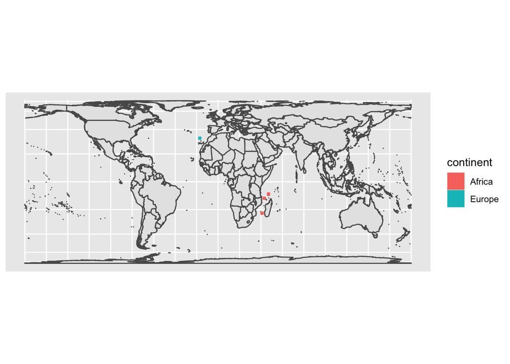

```r
full_missing <- full_complete %>% select(-plant_medium_plant_phylo)

full_missing <- full_missing[rowSums(is.na(full_missing)) > 0,]

ggplot() +
  geom_sf(data = world_base) +
  geom_sf(data = full_missing, aes(fill = continent, color = continent))
```

What is the sample size per cell? These are info-rich cells, but there are too many variables to get this info back from to where I don’t think the effort is worth it. I’m going to remove them and call it good.

```r
full_missing %>% select(continent, num_otu, num_ind, num_order)
```

```
## Simple feature collection with 4 features and 4 fields
## geometry type:  POLYGON
## dimension:      XY
## bbox:           xmin: -1734530 ymin: -2932287 xmax: 4634470 ymax: 4015713
## CRS:            +proj=cea +lon_0=0 +lat_ts=30 +x_0=0 +y_0=0 +datum=WGS84 +units=m +no_defs +ellps=WGS84 +towgs84=0,0,0
##     continent num_otu num_ind num_order                       geometry
## 481    Europe      22      96         4 POLYGON ((-1734530 4015713,...
## 742    Africa      19      66         2 POLYGON ((4441470 -1002287,...
## 755    Africa      69     619         2 POLYGON ((4055470 -1388287,...
## 832    Africa      10      70         1 POLYGON ((3862470 -2739287,...
```

Remove the plant richness column and filter NAs. Also adding in latitude and longitude columns.

```r
full_filter <- full_complete %>%
  select(-plant_medium_plant_phylo) %>%
  remove_missing()
# get centroid coordinate for each cell
coords <- st_centroid(full_filter) %>%
  st_coordinates()
full_filter <- full_filter %>%
  mutate(longitude = coords[,1],
         latitude = coords[,2])

glimpse(full_filter)
```

```
## Rows: 953
## Columns: 64
## $ cell                     <dbl> 48, 52, 55, 59, 96, 97, 98, 192, 211, 230, 2…
## $ avg_pi                   <dbl> 0.001454716, 0.001984298, 0.001503509, 0.001…
## $ median_pi                <dbl> 0.0000000000, 0.0008151743, 0.0006496771, 0.…
## $ sqrt_pi                  <dbl> 0.03814074, 0.04454546, 0.03877511, 0.037239…
## $ sd_pi                    <dbl> 0.002743044, 0.002742850, 0.002959823, 0.001…
## $ var_pi                   <dbl> 7.524288e-06, 7.523227e-06, 8.760551e-06, 3.…
## $ num_ind                  <dbl> 168, 5839, 3080, 122, 937, 392, 614, 660, 20…
## $ num_otu                  <dbl> 31, 97, 44, 13, 47, 35, 68, 37, 74, 19, 106,…
## $ num_order                <dbl> 3, 2, 2, 3, 5, 3, 2, 2, 3, 2, 4, 6, 3, 6, 8,…
## $ hill_1                   <dbl> 0.3062532, 0.4725420, 0.3445770, 0.4787828, …
## $ hill_2                   <dbl> 0.2251809, 0.3459020, 0.2088839, 0.3557687, …
## $ hill_3                   <dbl> 0.1876479, 0.2870740, 0.1535659, 0.2968241, …
## $ hill_4                   <dbl> 0.1680376, 0.2531603, 0.1293904, 0.2668610, …
```

[output cut: 51 more lines]

Map the latitude to make sure I got the correct column.

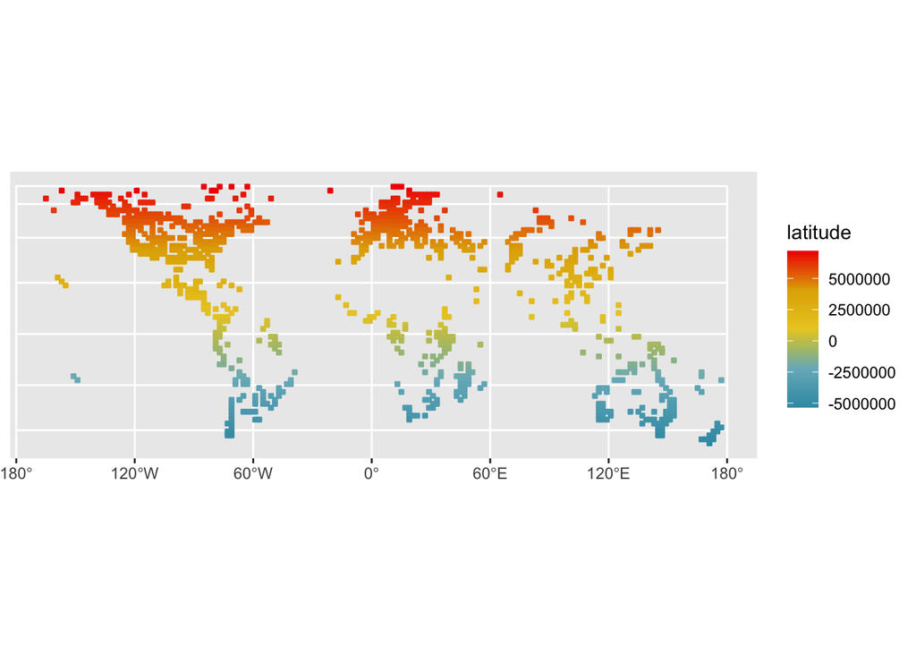

```r
ggplot() +
  geom_sf(data = full_filter, aes(fill = latitude, color = latitude)) +
  scale_fill_gradientn(colors = pal) +
  scale_color_gradientn(colors = pal)
```